# Metagenomic Profiles of Archaea and Bacteria within Thermal and Geochemical Gradients of the Guaymas Basin Deep Subsurface

David Geller-McGrath

May 30, 2023

This code was used for the analyses of Guaymas Basin metagenomes and metatranscriptomes for the 2023 publication “Metagenomic Profiles of Archaea and Bacteria within Thermal and Geochemical Gradients of the Guaymas Basin Deep Subsurface” by Geller-McGrath et al. Some sections of these analyses were done on a compute node of the Poseidon High Performance Computing (HPC) cluster based at the Woods Hole Oceanographic Institute (WHOI). All of the analyses done here using R can be run locally; HPC processing was used to speed up computations.

Load required R libraries

```r
library(tidyverse)
library(vroom)
library(ComplexHeatmap)
library(gridtext)
library(RColorBrewer)
library(ecodist)
library(vegan)
library(ape)
library(ggrepel)
library(latex2exp)
```

## Format MAG bins from DAS Tool and MAG complenetess/contamination estimates from CheckM2

```r
library(tidyverse)

dasTool_summary_dec_2022 = read_tsv('~/Downloads/Guaymas_MAG_P__DASTool_summary.tsv', show_col_types = FALSE)


checkm2_bins = read_tsv('flat_files/andreas_mags_checkm2_quality_report.tsv', show_col_types = FALSE) |>
  rename_with(~ str_to_lower(.x)) |>
  select(-`translation_table used`)


gtdb_bins = read_tsv('flat_files/andreas_gtdbtk_archaea.tsv', show_col_types = FALSE) |>
  bind_rows(read_tsv('flat_files/andreas_gtdbtk_bacteria.tsv', show_col_types = FALSE)) |>
  select(user_genome, classification) |>
  rename(mag_name = user_genome)


taxonomic_ranks = c("domain", "phylum", "class", "order", "family", "genus", "species")


gtdb_bins = gtdb_bins |>
  separate(classification, into = taxonomic_ranks, sep = ';') |>
  mutate(across(all_of(taxonomic_ranks), ~ str_replace(.x, '^[:alpha:]__', ''))) |>
  mutate(across(all_of(taxonomic_ranks), ~ if_else(.x == '', NA_character_, .x))) |>
  arrange(domain, phylum)


magSummary = dasTool_summary_dec_2022 |>
  left_join(checkm2_bins |> rename(bin = name), by = 'bin') |>
  left_join(gtdb_bins |> rename(bin = mag_name), by = 'bin') |>
  relocate(c(completeness, contamination, bin_score,
             taxonomic_ranks, SCG_completeness, SCG_redundancy),
           .before = bin)


# 125 MAGs that are not contaminants
# 89 that are >= 50% completeness, <= 10% contamination
magSummary = magSummary |>
  filter(
    !phylum %in% c('Firmicutes', 'Actinobacteriota', 'Patescibacteria'), # remove contaminant MAGs
    !class %in% c('Gammaproteobacteria'), # remove contaminant MAGs
    completeness >= 50,
    contamination <= 10)


magSummary = magSummary |>
  arrange(desc(completeness),  desc(contamination)) |>
  mutate(mag_name = paste0(
    'Guaymas_MAG_P_',
    1:nrow(magSummary) |> str_pad(width = 3, side = 'left', pad = '0')),
    .before = 1)


#13 unique bacterial phyla recovered
magSummary |>
  filter(domain == 'Bacteria') |>
  pull(phylum) |>
  unique() |>
  length()
```

```
## [1] 13
```

```r
#6 unique archaeal phyla recovered
magSummary |>
  filter(domain == 'Archaea') |>
  pull(phylum) |>
  unique() |>
  length()
```

```
## [1] 6
```

## Figure 2. MAG relative abundances

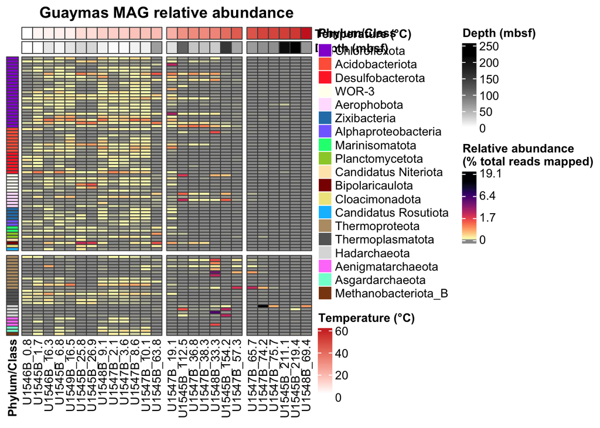

```r
# Figure 2
magSummary = read_tsv('~/Documents/guaymas_analysis/flat_files/filteredMagSummary.tsv')

envGeoData = read_tsv('~/Documents/guaymas_analysis/flat_files/environmentalGeochemicalData.tsv')


guay_relAbun_files = system('ls flat_files/mag_relative_abundance_coverM/new_rel_abun_dec_2022/*.tsv',
                            intern = TRUE)


guay_relAbun_tbl = guay_relAbun_files |>
  map(~ read_tsv(.x, show_col_types = FALSE)) |>
  reduce(left_join, by = 'Genome')


guay_relAbun_tbl = guay_relAbun_tbl |>
  rename_with(~ str_replace(.x, '(.*)_(.*)_S\\d+.*', '\\1\\2')) |>
  rename_with(~ str_replace(.x, '(.*)-(.*)_S\\d+.*', '\\1_\\2')) |>
  rename_with(~ str_replace(.x, '^U(.*B)(.*)', '\\1_\\2')) |>
  rename(bin = Genome) |>
  slice(-1) |> # remove the unmapped % information; won't be used in the heatmap
  left_join(magSummary |>
              select(mag_name, bin),
            by = 'bin') |>
  relocate(mag_name, .before = 1) |>
  filter(!is.na(mag_name)) |>
  select(-bin)


chloroflexota_percent_abundance = guay_relAbun_tbl |>
  left_join(magSummary |>
              select(mag_name, phylum)) |>
  filter(phylum == 'Chloroflexota') |>
  select(-phylum) |>
  summarize(across(2:last_col(), ~ sum(.x))) |>
  pivot_longer(
    cols = 2:last_col(),
    names_to = 'sample',
    values_to = 'chloroflexota_percent_abundance'
  )


guayMagRelPalette = list(
  `Phylum/Class` = c(
    'Candidatus Niteriota'  =   'wheat1',
    'Acidobacteriota'   =   'tomato',
    'Aenigmatarchaeota' =   'orchid1',
    'Aerophobota'   =   'thistle1',
    'Alphaproteobacteria'   =   'slateblue1',
    'Asgardarchaeota'   =   'aquamarine',
    'Atribacterota' =   'gold',
    'Bipolaricaulota'   =   'darkred',
    'Chloroflexota' =   'darkviolet',
    'Cloacimonadota'    =   'khaki',
    'Desulfobacterota'  =   'firebrick1',
    'Hadarchaeota'  =   'gainsboro',
    'Marinisomatota'    =   'springgreen',
    'Methanobacteriota_B'   =   'chocolate4',
    'Planctomycetota'   =   'yellowgreen',
    'Candidatus Rosutiota'  =   'deepskyblue',
    'Thermoplasmatota'  =   '#666666',
    'Thermoproteota'    =   '#B89B74',
    'Unclassified'  =   'lightsteelblue1',
    'WOR-3' =   'ivory',
    "Zixibacteria"  =   '#2A7FB7'),

  `Depth (mbsf)` = c('white', 'black'),

  Site = brewer.pal(8, 'Pastel2')[3:7] |>
    set_names('U1545B', 'U1546B', 'U1547B', 'U1548B', 'U1549B'))

guay_relAbun_plot_data =
  guay_relAbun_tbl |>
  mutate(across(2:last_col(), ~ log1p(.x))) |>
  left_join(magSummary |>
              select(mag_name, domain, phylum, class),
            by = 'mag_name') |>
  mutate(`Phylum/Class` = case_when(
    class == 'Alphaproteobacteria' ~ 'Alphaproteobacteria',
    is.na(phylum) ~ 'Unclassified',
    TRUE ~ phylum)) |>
  select(-c(class, phylum)) |>
  relocate(c(domain, `Phylum/Class`), .after = 1) |>
  group_by(`Phylum/Class`) |>
  mutate(group_total = n()) |>
  ungroup() |>
  arrange(factor(domain, levels = c('Bacteria', 'Archaea')),
          desc(group_total), `Phylum/Class`) |>
  select(-c(domain, `Phylum/Class`, group_total)) |>
  column_to_rownames('mag_name')


guayMagRelAbun_rowAnno = guay_relAbun_tbl |>
  select(mag_name) |>
  left_join(magSummary |>
              select(mag_name, domain, phylum, class),
            by = 'mag_name') |>
  mutate(`Phylum/Class` = case_when(
    class == 'Alphaproteobacteria' ~ 'Alphaproteobacteria',
    is.na(phylum) ~ 'Unclassified',
    TRUE ~ phylum)) |>
  select(-c(class, phylum)) |>
  column_to_rownames('mag_name')



guay_row_anno = guay_relAbun_tbl |>
  mutate(across(2:last_col(), ~ log1p(.x))) |>
  left_join(magSummary |>
              select(mag_name, domain, phylum, class),
            by = 'mag_name') |>
  mutate(`Phylum/Class` = case_when(
    class == 'Alphaproteobacteria' ~ 'Alphaproteobacteria',
    is.na(phylum) ~ 'Unclassified',
    TRUE ~ phylum)) |>
  select(-c(class, phylum)) |>
  relocate(c(domain, `Phylum/Class`), .after = 1) |>
  group_by(`Phylum/Class`) |>
  mutate(group_total = n()) |>
  ungroup() |>
  arrange(factor(domain, levels = c('Bacteria', 'Archaea')),
          desc(group_total), `Phylum/Class`) |>
  select(mag_name, `Phylum/Class`) |>
  mutate(`Phylum/Class` = case_when(
    `Phylum/Class` == 'TA06_A' ~ 'Candidatus Rosutiota',
    `Phylum/Class` == '4484-113' ~ 'Candidatus Niteriota',
    TRUE ~ `Phylum/Class`),
    `Phylum/Class` = fct_inorder(`Phylum/Class`)) |>
  column_to_rownames('mag_name')


metagenome_sample_metadata = read_tsv('flat_files/metagenome_sample_name_metadata.tsv')


guay_col_anno = metagenome_sample_metadata |>
  mutate(Sample = paste0('U', Sample)) |>
  left_join(envGeoData |>
              select(-c(`Depth (mbsf)`)),
            by = c('Sample' = 'sample')) |>
  column_to_rownames('Sample')


guay_relAbun_plot_data = guay_relAbun_plot_data |>
  rename_with(~ paste0('U', .x), .cols = everything()) |>
  rownames_to_column('mag_name') |>
  relocate(c(mag_name, envGeoData$sample))


guayMagRelPalette$`Temperature (°C)` = c('white', 'firebrick3')


heat_figure2_new = tibble(
  col = colnames(guay_relAbun_plot_data |>
                   column_to_rownames('mag_name') |>
                   #rename_with(~ paste0('U', .x)) |>
  relocate(guay_col_anno |>
             select(`Depth (mbsf)`, `T`) |>
             rename(`Temperature (°C)` = `T`) |>
             arrange(`Temperature (°C)`) |>
             rownames()))) |>
  left_join(envGeoData |>
              select(1:3) |>
              rename(col = sample))

heat_figure2_new = heat_figure2_new |>
  select(-`T`) |>
  rename(depth = 2) |>
  mutate(col_names = col |> str_replace("(.*_).*", paste0("\\1", depth))) |>
  select(-depth)


guay_relAbun_complexHeatmap =
  guay_relAbun_plot_data |>
  column_to_rownames('mag_name') |>
  #rename_with(~ paste0('U', .x)) |>
  relocate(guay_col_anno |>
             select(`Depth (mbsf)`, `T`) |>
             rename(`Temperature (°C)` = `T`) |>
             arrange(`Temperature (°C)`) |>
             rownames()) |>
  rename_with(~ heat_figure2_new$col_names, .cols = everything()) |>
  as.matrix() |>
  ComplexHeatmap::pheatmap(
    name = 'Relative abundance
(% total reads mapped)',
main = 'Guaymas MAG relative abundance',
show_colnames = TRUE,
annotation_row = guay_row_anno,
annotation_col = guay_col_anno |>
  select(`Depth (mbsf)`, `T`) |>
  rename(`Temperature (°C)` = `T`) |>
  arrange(`Temperature (°C)`),
annotation_colors = guayMagRelPalette,
cluster_rows = FALSE,
cluster_cols = FALSE,
show_rownames = FALSE,
gaps_row = 63,
gaps_col = c(13, 20),
border_color = 'grey30',
treeheight_row = 0,
treeheight_col = 10,
color = c('grey60', rev(viridis::magma(n = 50))),
legend_breaks = 0:3,
legend_labels = gt_render(c('0', sprintf('%.1f', round(expm1(1:3), 1)))),
show_row_dend = FALSE,
show_column_dend = TRUE)


draw(guay_relAbun_complexHeatmap,
     merge_legend = TRUE)
```

```r
# pdf(
#   file = '~/Documents/guaymas_analysis/june_15_all_manuscript_docs/figure_2.pdf',
#   width = 7,
#   height = 9)
# draw(guay_relAbun_complexHeatmap,
#      merge_legend = TRUE)
# dev.off()
```

## Figure 3. MAG transcript abundances

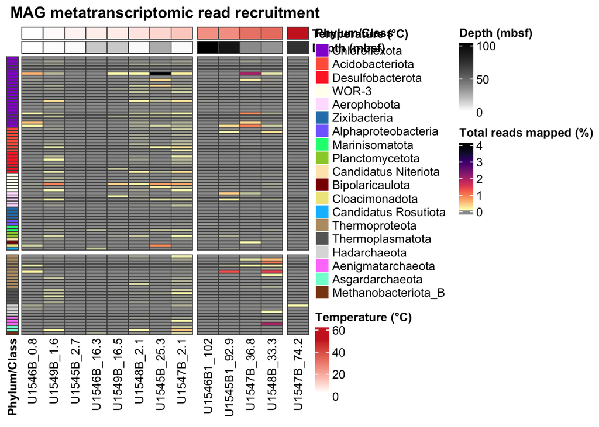

```r
# Figure 3

metaT_metadata = readRDS('rds_files/metaT_metadata')

genome_metaT_files = system('ls ~/Documents/guaymas_analysis/flat_files/reads_mapped_per_genome/*', intern = TRUE)

read_genome_metaT_data = function(.coverM_genome_TPM_file) {
  read_tsv(.coverM_genome_TPM_file, show_col_types = FALSE) |>
    rename(bin = Genome) |>
    filter(if_any(.cols = 2, ~ !is.na(.x))) |> #filter by col number, not col name
    select(1, 3) |> # select bin name col & col containing % total metaT reads mapped per MAG
    rename_with(~ str_replace(.x, '_R1_paired_fastx.fastq Relative Abundance \\(%\\)', ''))
}

mag_data_cols = c('mag_name', 'phylum', 'class', 'order', 'completeness')

genome_metaT_data = genome_metaT_files |>
  map(function(.file) {read_genome_metaT_data(.file)}) |>
  reduce(left_join, by = 'bin') |>
  left_join(magSummary |>
              select(mag_name, bin, phylum, class, order, completeness),
            by = 'bin') |>
  select(-bin) |>
  relocate(all_of(mag_data_cols)) |>
  filter(!is.na(mag_name)) |>
  arrange(phylum) |>
  mutate(phylum = case_when(
    phylum == 'TA06_A' ~ 'Candidatus Rosutiota',
    phylum == '4484-113' ~ 'Candidatus Niteriota',
    TRUE ~ phylum)) |>
  mutate(`Phylum/Class` = if_else(class == 'Alphaproteobacteria', class, phylum)) |>
  relocate(`Phylum/Class`, .after = 1) |>
  group_by(`Phylum/Class`) |>
  add_tally(n(), name = 'total') |>
  ungroup() |>
  relocate(total) |>
  arrange(desc(total), phylum, order) |>
  select(-total)
#select(-c(class, order, completeness))

genome_metaT_rowAnno = genome_metaT_data |>
  select(mag_name, `Phylum/Class`) |>
  mutate(`Phylum/Class` = as_factor(`Phylum/Class`)) |>
  column_to_rownames('mag_name')

genome_metaT_colAnno = metaT_metadata |>
  column_to_rownames('sample') |>
  rename(
    `Depth (mbsf)` = depth,
    Site = site) |>
  select(-Site)


metaT_env = read_tsv('~/Downloads/david_geochemistry_1.txt') |>
  rename(sample = Sample,
         Temperature = 6) |>
  mutate(sample = sample |> str_replace_all(
    c('U' = '', '-' = '')))


genome_metaT_colAnno = metaT_metadata |>
  rename(
    `Depth (mbsf)` = depth,
    Site = site) |>
  select(-Site) |>
  mutate(sample = sample |> str_replace('_', 'B')) |>
  left_join(metaT_env |>
              select(sample, Temperature),
            by = 'sample') |>
  rename(Temperature = 3) |>
  mutate(sample = sample |> str_replace('(.*B)(.*)', '\\1_\\2'),
         sample = paste0('U', sample)) |>
  column_to_rownames('sample')


genome_metaT_heat_data = genome_metaT_data |>
  select(-c(`Phylum/Class`, phylum, class, order, completeness)) |>
  column_to_rownames('mag_name')


metaT_mag_row_order = guay_row_anno |>
  rownames()

genome_metaT_colAnno_onlyMetagenomeSites = genome_metaT_colAnno |>
  rownames_to_column('sample') |>
  filter(str_detect(sample, '1545|1546|1547|1548|1549')) |>
  column_to_rownames('sample')

genome_metaT_heat_onlyMetagenomeSites = genome_metaT_heat_data |>
  relocate(metaT_metadata$sample) |>
  select(matches('1545.*|1546.*|1547.*|1548.*|1549.*'))


genome_metaT_rowAnno2 = genome_metaT_rowAnno |>
  rownames_to_column('mag_name') |>
  arrange(factor(mag_name, levels = metaT_mag_row_order)) |>
  column_to_rownames('mag_name') |>
  mutate(`Phylum/Class` = fct_inorder(`Phylum/Class`))



heat_figure2_metaT = metaT_env |>
  select(sample, `Depth (mbsf)`, Temperature) |>
  rename(col = sample, depth = `Depth (mbsf)`, temperature = Temperature) |>
  mutate(depth = round(depth, digits = 1),
    new_colname = col |>
           str_replace('(.*)(\\d+H\\d+)', paste0('U\\1_', depth))) |>
  arrange(temperature) |>
  filter(str_detect(col, '1545.*|1546.*|1547.*|1548.*|1549.*'))


metaT_heatmap =
  genome_metaT_heat_onlyMetagenomeSites |>
  rownames_to_column('mag_name') |>
  as_tibble() |>
  arrange(factor(mag_name, levels = metaT_mag_row_order)) |>
  column_to_rownames('mag_name') |>
  rename_with(~ paste0('U', .x) |> str_replace('(.*)(_.*)', '\\1B\\2')) |>
  relocate(genome_metaT_colAnno_onlyMetagenomeSites |>
             arrange(Temperature) |>
             rownames()) |>
  rename_with(~ heat_figure2_metaT |>
                arrange(temperature) |>
                pull(new_colname)) |>
  as.matrix() |>

  ComplexHeatmap::pheatmap(
    name = 'Total reads mapped (%)',
    main = 'MAG metatranscriptomic read recruitment',
    gaps_row = 63,
    gaps_col = c(8,12),
    show_colnames = TRUE,
    show_rownames = FALSE,
    annotation_col = genome_metaT_colAnno_onlyMetagenomeSites |>
      arrange(Temperature) |>
      rename(`Temperature (°C)` = Temperature),
    annotation_row = genome_metaT_rowAnno2,
    annotation_colors = guayMagRelPalette,
    cluster_rows = FALSE,
    cluster_cols = FALSE,
    border_color = 'grey30',
    treeheight_row = 0,
    treeheight_col = 10,
    color = c('grey60', rev(viridis::magma(n = 50))),
    show_row_dend = FALSE,
    show_column_dend = TRUE
    )

ComplexHeatmap::draw(metaT_heatmap, merge_legend = TRUE)
```

```r
# pdf(
#   file = '~/Documents/guaymas_analysis/june_15_all_manuscript_docs/figure_3.pdf',
#   width = 7,
#   height = 9)
# ComplexHeatmap::draw(metaT_heatmap,
#      merge_legend = TRUE)
# dev.off()
```

## Figure 4. Non-metric multidimensional scaling (nMDS) ordination plot of metagenomes reconstructed from sites U1545B, U1546B, U1547B, U1548B, U1549B and environmental parameters with a significant effect on microbial community composition (by temperature).

```r
envGeoData = read_tsv('~/Documents/guaymas_analysis/flat_files/environmentalGeochemicalData.tsv')

guay_tpm_files = system('ls flat_files/mag_relative_abundance_coverM/new_tpm_abun_dec_2022/*.tsv', intern = TRUE)

guay_tpm_tbl = guay_tpm_files |>
  map(~ read_tsv(.x, show_col_types = FALSE)) |>
  reduce(left_join, by = 'Genome') |>
  rename_with(~ str_replace(.x, '(.*)_(.*)_S\\d+.*', '\\1\\2')) |>
  rename_with(~ str_replace(.x, '(.*)-(.*)_S\\d+.*', '\\1_\\2')) |>
  rename_with(~ str_replace(.x, '^U(.*B)(.*)', '\\1_\\2')) |>
  rename(bin = Genome) |>
  left_join(magSummary |>
              select(mag_name, bin), by = 'bin') |>
  relocate(mag_name, .before = 1) |>
  filter(!is.na(mag_name)) |>
  select(-bin)

guay_tpm_pcoa_data = guay_tpm_tbl |>
  pivot_longer(
    cols = 2:last_col(),
    names_to = 'sample',
    values_to = 'value') |>
  left_join(metagenome_sample_metadata |>
              rename(sample = Sample),
            by = 'sample') |>
  select(-`Depth (mbsf)`) |>
  pivot_wider(
    names_from = sample,
    values_from = value) |>
  unnest(everything()) |>
  relocate(c(mag_name, metagenome_sample_metadata$Sample)) |>
  pivot_longer(
    cols = 2:last_col(),
    names_to = 'sample',
    values_to = 'relative_abundance') |>
  pivot_wider(
    names_from = mag_name,
    values_from = relative_abundance) |>
  column_to_rownames('sample')

guay_tpm_pcoa_data_FINAL = guay_tpm_pcoa_data

set.seed(123)
dist = guay_tpm_pcoa_data_FINAL |>
  vegdist(method = 'bray')


nmds_result_FINAL = metaMDS(
  dist,
  trymax = 10000,
  autotransform = TRUE)
```

```
## *** Best solution repeated 4 times
```

```r
nmds_scores_FINAL = scores(nmds_result_FINAL, "site") |>
  as.data.frame() %>%
  mutate(sample = rownames(.),
         sample = paste0('U', sample)) |>
  as_tibble() |>
  left_join(envGeoData, by = 'sample') |>
  mutate(Site = str_replace(
    sample, '(\\d{4}[:upper:]).*', '\\1'))


FINAL_nmds_envFit = envfit(
  nmds_result_FINAL,
  envGeoData[-c(1,2)],
  na.rm = TRUE,
  permutations = 10000)


FINAL_nmds_envScores = as.data.frame(scores(FINAL_nmds_envFit, display = 'vectors')) %>%
  mutate(env_variable = rownames(.),
         pvalue = FINAL_nmds_envFit$vectors$pvals) |>
  filter(pvalue <= 0.05)

FINAL_nmds_envScores
```

|  | NMDS1 | NMDS2 | env_variable | pvalue |
| --- | --- | --- | --- | --- |
| T | 0.9463819 | 0.1640094 | T | 0.00009999 |
| pH | -0.6726684 | 0.1375854 | pH | 0.00199980 |
| Salinity | -0.5888062 | 0.1275238 | Salinity | 0.01089891 |
| PO43- (uM) | -0.1719242 | 0.4723300 | PO43- (uM) | 0.04719528 |
| H2S (uM) | 0.2895239 | 0.4225214 | H2S (uM) | 0.04959504 |
| CO (nM) | -0.6579234 | -0.4782708 | CO (nM) | 0.00019998 |
| TOC (wt%) | -0.5072459 | -0.5693730 | TOC (wt%) | 0.00019998 |
| TN (wt%) | -0.3406890 | -0.5404748 | TN (wt%) | 0.00729927 |

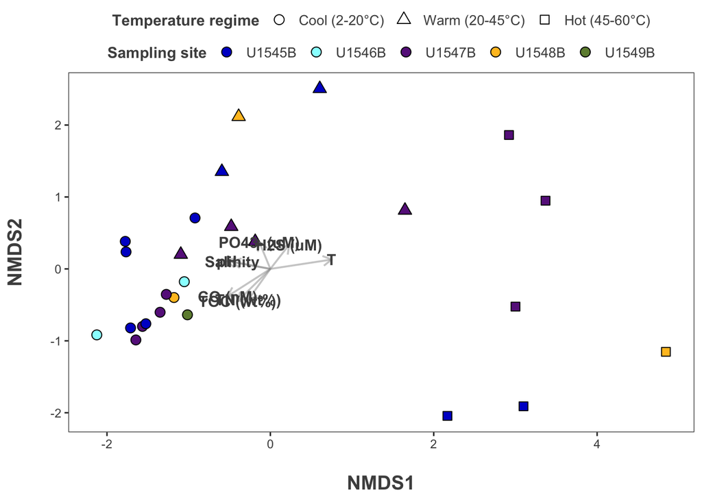

```r
nmds_scores_FINAL = nmds_scores_FINAL |>
  rename(depth = `Depth (mbsf)`) |>
  mutate(depth_bin = case_when(
    depth < 15 ~ 'Shallow (0-15 mbsf)',
    depth >= 15 & depth < 60 ~ 'Intermediate (15-60 mbsf)',
    depth >= 60 ~ 'Deep (> 60 mbsf)'),

    temp_bin = case_when(
    `T` > 2 & `T` <= 20 ~ 'Cool (2-20°C)',
    `T` > 20 & `T` <= 45 ~ 'Warm (20-45°C)',
    `T` > 45 ~ 'Hot (45-60°C)'), .after = `T`)


en_coord_cont = as.data.frame(scores(FINAL_nmds_envFit, "vectors")) *
  ordiArrowMul(FINAL_nmds_envFit)

en_coord_cont = en_coord_cont |>
  rownames_to_column('parameter') |>
  filter(parameter %in% FINAL_nmds_envScores$env_variable) |>
  column_to_rownames('parameter')



# figure 4 - nmds by temperature
mag_nmds_may_2023 = nmds_scores_FINAL |>
  mutate(temp_bin = if_else(temp_bin == 'Temperate (20-45°C)', 'Warm (20-45°C)', temp_bin)) |>

  ggplot(aes(x = NMDS1, y = NMDS2)) +
  geom_point(aes(fill = Site, shape = factor(
    temp_bin,
    levels = c('Cool (2-20°C)',
               'Warm (20-45°C)',
               'Hot (45-60°C)'))),
    size = 3) +
  geom_segment(aes(x = 0, y = 0, xend = NMDS1, yend = NMDS2),
               data = en_coord_cont, size = 0.65, alpha = 0.5, colour = "grey60",
               arrow = arrow(length = unit(0.25, 'cm'))) +
  geom_text(data = en_coord_cont, aes(x = NMDS1, y = NMDS2), colour = "grey30",
            fontface = "bold", label = row.names(en_coord_cont)) +
  theme(axis.title = element_text(size = 14, face = "bold", colour = "grey30"),
        panel.background = element_blank(),
        panel.border = element_rect(fill = NA, colour = "grey30"),
        legend.title = element_text(size = 11, face = "bold", colour = "grey30"),
        legend.text = element_text(size = 10, colour = "grey30"),
        legend.position = 'top',
        legend.box = 'vertical',
        legend.key = element_blank(),
        legend.margin = margin(b = -5),) +
  labs(x = '\nNMDS1',
       y = 'NMDS2\n',
       shape = 'Temperature regime',
       fill = 'Sampling site') +
  scale_fill_manual(values = c(
    'U1545B' = 'mediumblue',
    'U1546B' = 'darkslategray1',
    'U1547B' = 'darkorchid4',
    'U1548B' = 'goldenrod1',
    'U1549B' = 'darkolivegreen4')) +
  scale_shape_manual(values = c(
    'Cool (2-20°C)' = 21,
    'Warm (20-45°C)' = 24,
    'Hot (45-60°C)' = 22)) +
  scale_color_manual(values = 'black') +
  guides(fill = guide_legend(override.aes = list(shape = 21)))
mag_nmds_may_2023
```

```r
ggsave(
  filename = '~/Documents/guaymas_analysis/june_15_all_manuscript_docs/figure_4.pdf',
  plot = mag_nmds_may_2023,
  width = 8,
  height = 8
)
```

## Figure 5. Genome size analysis (boxplots and linear regression)

```r
library(tidyverse)
library(vroom)
library(ComplexHeatmap)
library(gridtext)
library(RColorBrewer)
library(cowplot)
library(latex2exp)

guay_relAbun_files = system('ls flat_files/mag_relative_abundance_coverM/new_rel_abun_dec_2022/*.tsv', intern = TRUE)

abund = guay_relAbun_files |>
  map(~ read_tsv(.x, show_col_types = FALSE)) |>
  reduce(left_join, by = 'Genome') |>
  rename_with(~ str_replace(.x, '(.*)_(.*)_S\\d+.*', '\\1\\2')) |> #colnames()
  rename_with(~ str_replace(.x, '(.*)-(.*)_S\\d+.*', '\\1_\\2')) |>  #colnames()
  rename_with(~ str_replace(.x, '^U(.*B)(.*)', '\\1_\\2')) |>
  rename_with(~ str_replace(.x, '(.*)', 'U\\1'), .cols = 2:last_col()) |>
  rename(bin = Genome) |>
  #slice(-1) |>  # remove the unmapped % information; won't be used in the heatmap
  mutate(across(2:last_col(), ~ round(.x, digits = 1))) |>
  left_join(magSummary |> select(mag_name, bin), by = 'bin') |>
  relocate(mag_name, .before = 1) |>
  filter(!is.na(mag_name), bin != 'unmapped') |>
  select(-bin)




# significance test - by depth

sample_groups_depth = envGeoData |>
  rename(depth = 2, temperature = 3) |>
  select(sample, depth, temperature) |>
  mutate(depth_group = case_when(
    depth <= 15 ~ 'shallow',
    depth > 15 & depth <= 60 ~ 'intermediate',
    depth > 60 ~ 'deep'),
    temperature_group = case_when(
      temperature <= 20 ~ 'cool',
      temperature > 20 & temperature <= 45 ~ 'warm',
      temperature > 45 ~ 'hot')) |>
  group_by(depth_group) |>
  group_split() %>%
  set_names(map_chr(., ~ unique(.x$depth_group)))

shallow_samples = sample_groups_depth$shallow
intermediate_samples = sample_groups_depth$intermediate
deep_samples = sample_groups_depth$deep


shallow_mags = abund |>
  select(mag_name, shallow_samples$sample) |>
  filter(if_any(.cols = 2:last_col(), ~ .x > 0)) |>
  left_join(magSummary |>
              mutate(completeness = completeness / 100,
                est_genome_size = size / completeness) |>
              select(mag_name, est_genome_size),
            by = 'mag_name') |>
  relocate(est_genome_size, .after = mag_name)

intermediate_mags = abund |>
  select(mag_name, intermediate_samples$sample) |>
  filter(if_any(.cols = 2:last_col(), ~ .x > 0)) |>
  left_join(magSummary |>
              mutate(completeness = completeness / 100,
                     est_genome_size = size / completeness) |>
              select(mag_name, est_genome_size),
            by = 'mag_name') |>
  relocate(est_genome_size, .after = mag_name)


deep_mags = abund |>
  select(mag_name, deep_samples$sample) |>
  filter(if_any(.cols = 2:last_col(), ~ .x > 0)) |>
  left_join(magSummary |>
              mutate(completeness = completeness / 100,
                     est_genome_size = size / completeness) |>
              select(mag_name, est_genome_size),
            by = 'mag_name') |>
  relocate(est_genome_size, .after = mag_name)


# mean(shallow_mags$est_genome_size)
# mean(intermediate_mags$est_genome_size)
# mean(deep_mags$est_genome_size)
# mean(shallow_mags$est_genome_size) / mean(deep_mags$est_genome_size)


# two-sided Welch's t-test
t.test(shallow_mags$est_genome_size, deep_mags$est_genome_size)
```

```
##
##  Welch Two Sample t-test
##
## data:  shallow_mags$est_genome_size and deep_mags$est_genome_size
## t = 2.2792, df = 48.37, p-value = 0.02711
## alternative hypothesis: true difference in means is not equal to 0
## 95 percent confidence interval:
##   47620.63 759484.79
## sample estimates:
## mean of x mean of y
##   2255632   1852080
```

```r
t.test(intermediate_mags$est_genome_size, deep_mags$est_genome_size)
```

```
##
##  Welch Two Sample t-test
##
## data:  intermediate_mags$est_genome_size and deep_mags$est_genome_size
## t = 1.9425, df = 42.176, p-value = 0.05877
## alternative hypothesis: true difference in means is not equal to 0
## 95 percent confidence interval:
##  -12735.44 669782.41
## sample estimates:
## mean of x mean of y
##   2180603   1852080
```

```r
t.test(shallow_mags$est_genome_size, intermediate_mags$est_genome_size)
```

```
##
##  Welch Two Sample t-test
##
## data:  shallow_mags$est_genome_size and intermediate_mags$est_genome_size
## t = 0.50284, df = 117.86, p-value = 0.616
## alternative hypothesis: true difference in means is not equal to 0
## 95 percent confidence interval:
##  -220452.9  370511.4
## sample estimates:
## mean of x mean of y
##   2255632   2180603
```

```r
# adjust the above p-values for multiple comparisons
p.adjust(c(0.02711, 0.05877, 0.616), method = 'BH')
```

```
## [1] 0.081330 0.088155 0.616000
```

```r
mags_depth = shallow_mags |>
  select(mag_name, est_genome_size) |>
  mutate(depth_group = 'shallow') |>
  bind_rows(
    intermediate_mags |>
      select(mag_name, est_genome_size) |>
      mutate(depth_group = 'intermediate')) |>
  bind_rows(
    deep_mags |>
      select(mag_name, est_genome_size) |>
      mutate(depth_group = 'deep'))


# by temperature

sample_groups_temperature = envGeoData |>
  rename(depth = 2, temperature = 3) |>
  select(sample, depth, temperature) |>
  mutate(depth_group = case_when(
    depth <= 15 ~ 'shallow',
    depth > 15 & depth <= 60 ~ 'intermediate',
    depth > 60 ~ 'deep'),
    temperature_group = case_when(
      temperature <= 20 ~ 'cool',
      temperature > 20 & temperature <= 45 ~ 'warm',
      temperature > 45 ~ 'hot')) |>
  group_by(temperature_group) |>
  group_split() %>%
  set_names(map_chr(., ~ unique(.x$temperature_group)))

cool_samples = sample_groups_temperature$cool
warm_samples = sample_groups_temperature$warm
hot_samples = sample_groups_temperature$hot


cool_mags = abund |>
  select(mag_name, cool_samples$sample) |>
  filter(if_any(.cols = 2:last_col(), ~ .x > 0)) |>
  left_join(magSummary |>
              mutate(completeness = completeness / 100,
                     est_genome_size = size / completeness) |>
              select(mag_name, est_genome_size),
            by = 'mag_name') |>
  relocate(est_genome_size, .after = mag_name)

warm_mags = abund |>
  select(mag_name, warm_samples$sample) |>
  filter(if_any(.cols = 2:last_col(), ~ .x > 0)) |>
  left_join(magSummary |>
              mutate(completeness = completeness / 100,
                     est_genome_size = size / completeness) |>
              select(mag_name, est_genome_size),
            by = 'mag_name') |>
  relocate(est_genome_size, .after = mag_name)


hot_mags = abund |>
  select(mag_name, hot_samples$sample) |>
  filter(if_any(.cols = 2:last_col(), ~ .x > 0)) |>
  left_join(magSummary |>
              mutate(completeness = completeness / 100,
                     est_genome_size = size / completeness) |>
              select(mag_name, est_genome_size),
            by = 'mag_name') |>
  relocate(est_genome_size, .after = mag_name)


# mean(cool_mags$est_genome_size)
# mean(warm_mags$est_genome_size)
# mean(hot_mags$est_genome_size)
mean(cool_mags$est_genome_size) / mean(hot_mags$est_genome_size)
```

```
## [1] 1.321028
```

```r
mean(warm_mags$est_genome_size) / mean(hot_mags$est_genome_size)
```

```
## [1] 1.20614
```

```r
# two-sided Welch's t-test
t.test(cool_mags$est_genome_size, hot_mags$est_genome_size)
```

```
##
##  Welch Two Sample t-test
##
## data:  cool_mags$est_genome_size and hot_mags$est_genome_size
## t = 3.9617, df = 14.068, p-value = 0.001406
## alternative hypothesis: true difference in means is not equal to 0
## 95 percent confidence interval:
##  251475.7 844591.3
## sample estimates:
## mean of x mean of y
##   2255155   1707121
```

```r
t.test(warm_mags$est_genome_size, hot_mags$est_genome_size)
```

```
##
##  Welch Two Sample t-test
##
## data:  warm_mags$est_genome_size and hot_mags$est_genome_size
## t = 2.2333, df = 20.282, p-value = 0.03694
## alternative hypothesis: true difference in means is not equal to 0
## 95 percent confidence interval:
##   23514.22 680296.81
## sample estimates:
## mean of x mean of y
##   2059027   1707121
```

```r
t.test(cool_mags$est_genome_size, warm_mags$est_genome_size)
```

```
##
##  Welch Two Sample t-test
##
## data:  cool_mags$est_genome_size and warm_mags$est_genome_size
## t = 1.2657, df = 86.521, p-value = 0.209
## alternative hypothesis: true difference in means is not equal to 0
## 95 percent confidence interval:
##  -111894.1  504150.1
## sample estimates:
## mean of x mean of y
##   2255155   2059027
```

```r
# adjust the above p-values for multiple comparisons
p.adjust(c(0.001406, 0.03694, 0.209), method = 'BH')
```

```
## [1] 0.004218 0.055410 0.209000
```

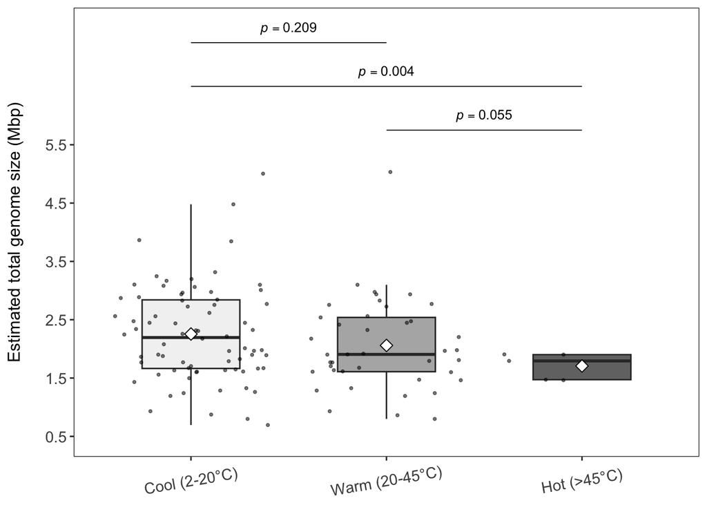

```r
mags_temperature = cool_mags |>
  select(mag_name, est_genome_size) |>
  mutate(temperature_group = 'cool') |>
  bind_rows(
    warm_mags |>
      select(mag_name, est_genome_size) |>
      mutate(temperature_group = 'warm')) |>
  bind_rows(
    hot_mags |>
      select(mag_name, est_genome_size) |>
      mutate(temperature_group = 'hot'))



# boxplots

# temperature boxplot
temperature_mag_size_boxplot_plot = mags_temperature |>
  mutate(
    est_genome_size = est_genome_size / 1e06,
    temperature_group = case_when(
      temperature_group == 'cool' ~ 'Cool (2-20°C)',
      temperature_group == 'warm' ~ 'Warm (20-45°C)',
      temperature_group == 'hot' ~ 'Hot (>45°C)'),

    temperature_group = factor(temperature_group,
                               levels = c('Cool (2-20°C)',
                                          'Warm (20-45°C)',
                                          'Hot (>45°C)'))) |>
  ggplot(aes(
    y = est_genome_size,
    x = temperature_group,
    fill = temperature_group)) +
  geom_boxplot(
    outlier.shape = NA,
    width = 0.5) +
  stat_summary(fun = mean, geom = "point", shape = 23,
               size = 3, fill = "white", color = "black") +
  geom_jitter(color = "black", size = 0.7, alpha = 0.5) +
  theme_bw() +
  theme(
    axis.title.y = element_text(size = 12),
    axis.text.y = element_text(size = 11),
    panel.grid = element_blank(),
    axis.text.x = element_text(size = 11, angle = 10, hjust = 0.5, vjust = 0.5),
    axis.title.x = element_blank(),
    #axis.ticks.x = element_blank(),
    legend.position = 'none') +
  labs(y = 'Estimated total genome size (Mbp)\n',
       fill = 'Temperature regime') +
  scale_fill_manual(
    values = c(
      'Cool (2-20°C)' = 'grey95',
      'Warm (20-45°C)' = 'grey70',
      'Hot (>45°C)' = 'grey45'
    )
  ) +
  #p-values
  annotate('text', x = 1.5, y = 7.5,
           label = 'italic(p) == 0.209',
           size = 3.4, parse = TRUE) +
  annotate('text', x = 2, y = 6.75,
           label = 'italic(p) == 0.004',
           size = 3.4, parse = TRUE) +
  annotate('text', x = 2.5, y = 6,
           label = 'italic(p) == 0.055',
           size = 3.4, parse = TRUE) +

  #segments
  annotate('segment', x = 1, xend = 2,
           y = 7.25, yend = 7.25,
           colour = 'black', size = 0.3) +
  annotate('segment', x = 1, xend = 3,
           y = 6.5, yend = 6.5,
           colour = 'black', size = 0.3) +
  annotate('segment', x = 2, xend = 3,
           y = 5.75, yend = 5.75,
           colour = 'black', size = 0.3) +

  scale_y_continuous(breaks = seq(0.5, 6, by = 1),
                     limits = c(0.5, 7.5))

temperature_mag_size_boxplot_plot
```

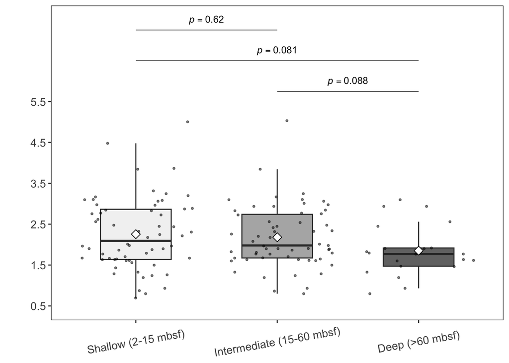

```r
# depth boxplot
depth_mag_size_boxplot_plot = mags_depth |>
  mutate(
    est_genome_size = est_genome_size / 1e06,
    depth_group = case_when(
      depth_group == 'shallow' ~ 'Shallow (2-15 mbsf)',
      depth_group == 'intermediate' ~ 'Intermediate (15-60 mbsf)',
      depth_group == 'deep' ~ 'Deep (>60 mbsf)'),

    depth_group = factor(depth_group,
                         levels = c('Shallow (2-15 mbsf)',
                                    'Intermediate (15-60 mbsf)',
                                    'Deep (>60 mbsf)'))) |>
  ggplot(aes(
    y = est_genome_size,
    x = depth_group,
    fill = depth_group)) +
  geom_boxplot(
    outlier.shape = NA,
    width = 0.5) +
  stat_summary(fun = mean, geom = "point",
               shape = 23, size = 3, fill = "white", color = "black") +
  geom_jitter(color = "black", size = 0.7, alpha = 0.5) +
  theme_bw() +
  theme(
    axis.text.y = element_text(size = 11),
    panel.grid = element_blank(),
    axis.text.x = element_text(size = 11, angle = 10, hjust = 0.5, vjust = 0.5),
    axis.title.x = element_blank(),
    legend.position = 'none',
    ) +
  labs(y = '\n',
       fill = 'Depth regime') +
  scale_fill_manual(values = c(
    'Shallow (2-15 mbsf)' = 'grey95',
    'Intermediate (15-60 mbsf)' = 'grey70',
    'Deep (>60 mbsf)' = 'grey45'
  )) +
  #p-values
  annotate('text', x = 1.5, y = 7.5,
           label = 'italic(p) == 0.62',
           size = 3.4, parse = TRUE) +
  annotate('text', x = 2, y = 6.75,
           label = 'italic(p) == 0.081',
           size = 3.4, parse = TRUE) +
  annotate('text', x = 2.5, y = 6,
           label = 'italic(p) == 0.088',
           size = 3.4, parse = TRUE) +

  #segments
  annotate('segment', x = 1, xend = 2,
           y = 7.25, yend = 7.25,
           colour = 'black', size = 0.3) +
  annotate('segment', x = 1, xend = 3,
           y = 6.5, yend = 6.5,
           colour = 'black', size = 0.3) +
  annotate('segment', x = 2, xend = 3,
           y = 5.75, yend = 5.75,
           colour = 'black', size = 0.3) +

  scale_y_continuous(breaks = seq(0.5, 6, by = 1),
                     limits = c(0.5, 7.5))

depth_mag_size_boxplot_plot
```

```r
# ggsave(
#   plot = depth_temperature_genome_size_boxplots,
#   filename = '~/Documents/guaymas_analysis/final_figures_and_tables/figure_5_boxplots.pdf',
#   width = 14,
#   height = 6,
#   dpi = 500,
#   units = 'in')






# linear regression


# temperature regression
mags_temperature_regression =
  cool_mags |>
  pivot_longer(cols = 3:last_col(),
               names_to = 'sample',
               values_to = 'percent_reads_mapped') |>
  filter(percent_reads_mapped > 0) |>
  mutate(temperature_group = 'cool') |>
  left_join(envGeoData |>
              select(sample, `T`),
            by = 'sample') |>
  #pull(`T`) |> is.na() |> table()
  bind_rows(
    warm_mags |>
      pivot_longer(cols = 3:last_col(),
                   names_to = 'sample',
                   values_to = 'percent_reads_mapped') |>
      filter(percent_reads_mapped > 0) |>
      mutate(temperature_group = 'cool') |>
      left_join(envGeoData |>
                  select(sample, `T`),
                by = 'sample') |>
      mutate(temperature_group = 'temperate')
  ) |>
  bind_rows(
    hot_mags |>
      pivot_longer(cols = 3:last_col(),
                   names_to = 'sample',
                   values_to = 'percent_reads_mapped') |>
      filter(percent_reads_mapped > 0) |>
      mutate(temperature_group = 'cool') |>
      left_join(envGeoData |>
                  select(sample, `T`),
                by = 'sample') |>
      mutate(temperature_group = 'hot')
  ) |>
  rename(temperature = `T`)



# run regression
temperature_regression_data = mags_temperature_regression |>
  mutate(
    est_genome_size = est_genome_size / 1e06) |>
  group_by(sample, temperature) |>
  summarize(ags = mean(est_genome_size), .groups = 'drop')

temperature_regression = lm(ags ~ temperature, data = temperature_regression_data)
summary(temperature_regression)
```

```
##
## Call:
## lm(formula = ags ~ temperature, data = temperature_regression_data)
##
## Residuals:
##      Min       1Q   Median       3Q      Max
## -0.31749 -0.06301  0.01826  0.07700  0.25320
##
## Coefficients:
##              Estimate Std. Error t value Pr(>|t|)
## (Intercept)  2.329101   0.050900  45.758  < 2e-16 ***
## temperature -0.012964   0.001636  -7.927 5.02e-08 ***
## ---
## Signif. codes:  0 '***' 0.001 '**' 0.01 '*' 0.05 '.' 0.1 ' ' 1
##
## Residual standard error: 0.1435 on 23 degrees of freedom
## Multiple R-squared:  0.732,  Adjusted R-squared:  0.7204
## F-statistic: 62.83 on 1 and 23 DF,  p-value: 5.022e-08
```

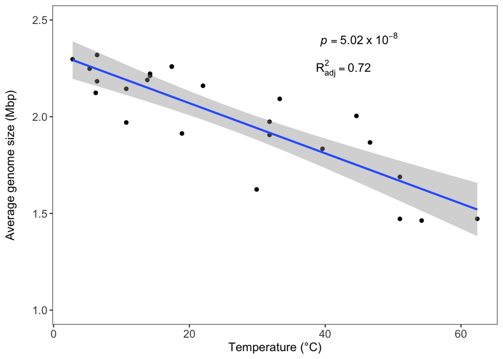

```r
temperature_mag_size_regression_plot =
  mags_temperature_regression |>
  mutate(
    est_genome_size = est_genome_size / 1e06,
    temperature_group = case_when(
      temperature_group == 'cool' ~ 'Cool (2-20°C)',
      temperature_group == 'temperate' ~ 'Temperate (20-45°C)',
      temperature_group == 'hot' ~ 'Hot (>45°C)'),
    temperature_group = factor(temperature_group,
                               levels = c('Cool (2-20°C)',
                                          'Temperate (20-45°C)',
                                          'Hot (>45°C)'))
  ) |>
  group_by(sample, temperature, temperature_group) |>
  summarize(ags = mean(est_genome_size), .groups = 'drop') |>
  ggplot(aes(
    y = ags,
    x = temperature
  )) +
  geom_point() +
  geom_smooth(method = 'lm', formula = y ~ x) +
  annotate('text', x = 45, y = 2.4,
           label = 'italic(p) == 5.02~x~10^{-8}',
           size = 4.2, parse = TRUE) +
  annotate('text', x = 42.7, y = 2.25,
           label = TeX('$R^{2}_{adj} = .72'),
           size = 4.2, parse = TRUE) +
  theme_bw() +
  theme(
    axis.title = element_text(size = 12),
    axis.text = element_text(size = 11),
    panel.grid = element_blank(),
    legend.position = 'top') +
  labs(y = 'Average genome size (Mbp)\n',
       x = 'Temperature (°C)') +
  scale_y_continuous(breaks = seq(1, 2.5, by = 0.5),
                     limits = c(1.0, 2.5))

temperature_mag_size_regression_plot
```

```r
# depth regression

mags_depth_regression =
  shallow_mags |>
  pivot_longer(cols = 3:last_col(),
               names_to = 'sample',
               values_to = 'percent_reads_mapped') |>
  filter(percent_reads_mapped > 0) |>
  mutate(temperature_group = 'shallow') |>
  left_join(envGeoData |>
              select(sample, `Depth (mbsf)`),
            by = 'sample') |>
  #pull(`Depth (mbsf)`) |> is.na() |> table()
  bind_rows(
    intermediate_mags |>
      pivot_longer(cols = 3:last_col(),
                   names_to = 'sample',
                   values_to = 'percent_reads_mapped') |>
      filter(percent_reads_mapped > 0) |>
      mutate(depth_group = 'intermediate') |>
      left_join(envGeoData |>
                  select(sample, `Depth (mbsf)`),
                by = 'sample')
  ) |>
  bind_rows(
    deep_mags |>
      pivot_longer(cols = 3:last_col(),
                   names_to = 'sample',
                   values_to = 'percent_reads_mapped') |>
      filter(percent_reads_mapped > 0) |>
      mutate(temperature_group = 'deep') |>
      left_join(envGeoData |>
                  select(sample, `Depth (mbsf)`),
                by = 'sample') |>
      mutate(temperature_group = 'deep')
  ) |>
  rename(depth = `Depth (mbsf)`)



# run regression
depth_regression_data = mags_depth_regression |>
  mutate(
    est_genome_size = est_genome_size / 1e06) |>
  group_by(sample, depth) |>
  summarize(ags = mean(est_genome_size), .groups = 'drop')

depth_regression = lm(ags ~ depth, data = depth_regression_data)
summary(depth_regression)
```

```
##
## Call:
## lm(formula = ags ~ depth, data = depth_regression_data)
##
## Residuals:
##      Min       1Q   Median       3Q      Max
## -0.42650 -0.05987  0.04392  0.06884  0.28772
##
## Coefficients:
##              Estimate Std. Error t value Pr(>|t|)
## (Intercept)  2.186540   0.044265  49.397  < 2e-16 ***
## depth       -0.004152   0.000642  -6.468 1.34e-06 ***
## ---
## Signif. codes:  0 '***' 0.001 '**' 0.01 '*' 0.05 '.' 0.1 ' ' 1
##
## Residual standard error: 0.1651 on 23 degrees of freedom
## Multiple R-squared:  0.6452, Adjusted R-squared:  0.6298
## F-statistic: 41.83 on 1 and 23 DF,  p-value: 1.339e-06
```

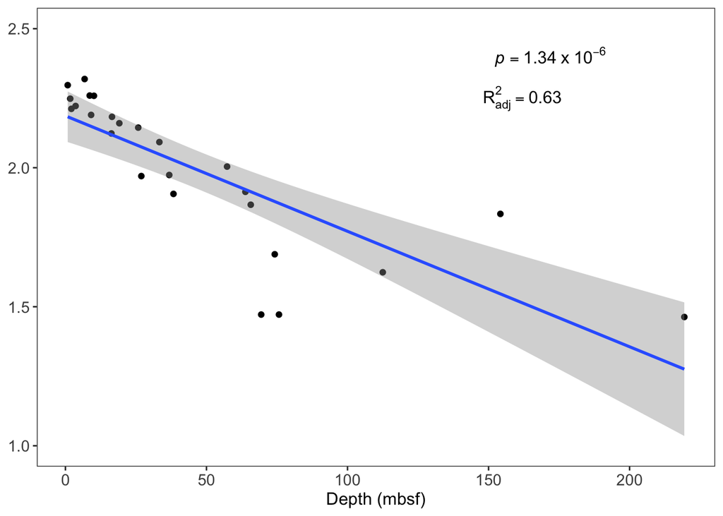

```r
# plot results
depth_mag_size_regression_plot =
  mags_depth_regression |>
  mutate(
    est_genome_size = est_genome_size / 1e06) |>
  group_by(sample, depth) |>
  summarize(ags = mean(est_genome_size), .groups = 'drop') |>
  ggplot(aes(
    y = ags,
    x = depth
  )) +
  geom_point() +
  geom_smooth(method = 'lm', formula= y ~ x) +
  annotate('text', x = 172, y = 2.4,
           label = 'italic(p) == 1.34~x~10^{-6}',
           size = 4.2, parse = TRUE) +
  annotate('text', x = 162, y = 2.25,
           label = TeX('$R^{2}_{adj} = .63'),
           size = 4.2, parse = TRUE) +
  theme_bw() +
  theme(
    axis.title = element_text(size = 12),
    axis.text = element_text(size = 11),
    panel.grid = element_blank(),
    axis.title.y = element_blank(),
    legend.position = 'top') +
  labs(y = 'Average genome size (Mbp)\n',
       x = 'Depth (mbsf)') +
  scale_y_continuous(breaks = seq(1, 2.5, by = 0.5),
                     limits = c(1.0, 2.5))


depth_mag_size_regression_plot
```

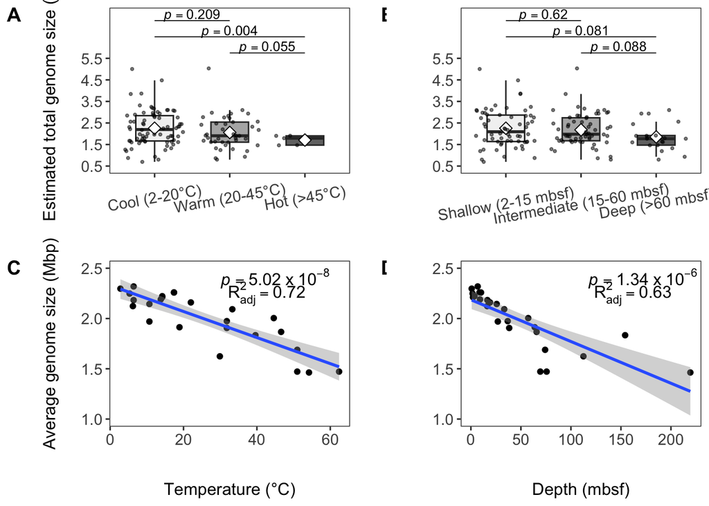

```r
figure_5_genome_size =
  plot_grid(
    ncol = 4,
    nrow = 2,
    rel_widths = c(0.11, 1, 0.09, 1),
    labels = c('A','','  B','','C','','  D',''),
    NULL,
    temperature_mag_size_boxplot_plot,
    NULL,
    depth_mag_size_boxplot_plot,

    NULL,
    temperature_mag_size_regression_plot,
    NULL,
    depth_mag_size_regression_plot,
    align = 'hv'
    )

figure_5_genome_size
```

```r
# ggsave(
#   plot = figure_5_genome_size,
#   filename = '~/Documents/guaymas_analysis/june_15_all_manuscript_docs/figure_5.pdf',
#   width = 10,
#   height = 10,
#   dpi = 500,
#   units = 'in')
```